# IODS course project

Donggyu Kam

# About the project

I am appreciated that I have an opportunity to learn such good tools

# Regression and Model Validation

## Regression

The data “students2014” is about the students attitude toward statistics. The data consists of information about students’ gender, student ages, deep approach(deep), surface appoarch(surf), strategic approach(stra), attitude toward statistics, points from exam and the students’ gender. WIth the data “students2014”, you can figure out that what variables affect the exam points through linear regression analysis.*

You can read the data and name the data “students2014” with the code “read.table”

*students2014<-read.table(“http://s3.amazonaws.com/assets.datacamp.com/production/course_2218/datasets/learning2014.txt”, sep=“,”, header=TRUE )*

Through the codes “dim()” and “str()”, you can take a look at the dimension and structure of data.

*dim(students2014)*

*str(students2014)*

You can compare all variables to find out what variable affect the most to the exam points, how the variables are distributed and how they are related to using the code “ggpairs()”.

*library(GGally)* *library(ggplot2)*

*pairs(students2014[-1], col=(students2014$gender))* *p <- ggpairs(students2014, mapping = aes(col=gender, alpha=0.3), lower = list(combo = wrap(“facethist”, bins = 20)))* *p*

*model1<-lm(points ~ attitude+stra+surf, data=students2014)* *summary(model1)*

## Output of the summary of model1

Call: lm(formula = points ~ attitude + stra + surf, data = students2014)

Residuals: Min 1Q Median 3Q Max -17.1550 -3.4346 0.5156 3.6401 10.8952

Coefficients: Estimate Std. Error t value Pr(>|t|) (Intercept) 11.0171 3.6837 2.991 0.00322 attitude 3.3952 0.5741 5.913 1.93e-08 stra 0.8531 0.5416 1.575 0.11716 surf -0.5861 0.8014 -0.731 0.46563

Residual standard error: 5.296 on 162 degrees of freedom Multiple R-squared: 0.2074, Adjusted R-squared: 0.1927 F-statistic: 14.13 on 3 and 162 DF, p-value: 3.156e-08

In this model, “Stra” and “suft” among three explanatory variables are not significantly related to exam points based on p-value. So, excluding the two variables, the model is fitted with “attitude” once again.

*model2<-lm(points ~ attitude, data=students2014)* *summary(model2)*

## Output of the model2

Call: lm(formula = points ~ attitude, data = students2014)

Residuals: Min 1Q Median 3Q Max -16.9763 -3.2119 0.4339 4.1534 10.6645

Residual standard error: 5.32 on 164 degrees of freedom Multiple R-squared: 0.1906, Adjusted R-squared: 0.1856 F-statistic: 38.61 on 1 and 164 DF, p-value: 4.119e-09

In model2, the summary indicates that the relationship between the exam point and attitude is significant correlated at 0.00000000412 p-value. And the mulitple R-squared value is 0.1906 so this model can explain 20% of the relataionship between the exam points and attitude.

## Assumption of Model and Model validation

# Chapter 5

### data

```r
human<-read.csv("http://s3.amazonaws.com/assets.datacamp.com/production/course_2218/datasets/human2.txt", sep=',', header= TRUE)
```

### overview and summary of the data

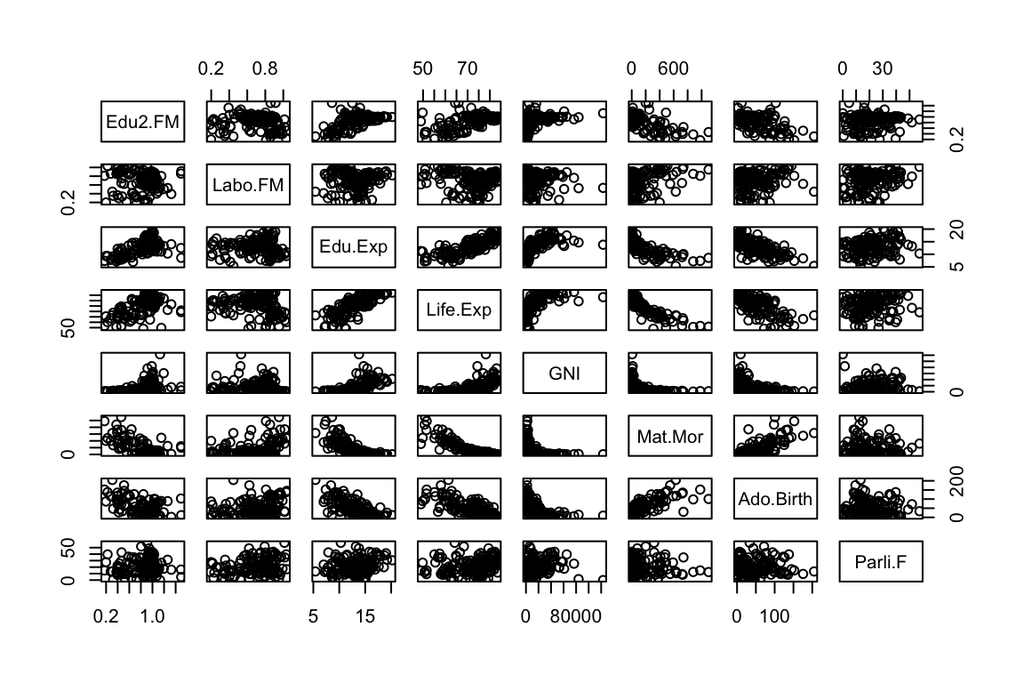

```r
pairs(human)
```

```r
summary(human)
```

```
##     Edu2.FM          Labo.FM          Edu.Exp         Life.Exp
##  Min.   :0.1717   Min.   :0.1857   Min.   : 5.40   Min.   :49.00
##  1st Qu.:0.7264   1st Qu.:0.5984   1st Qu.:11.25   1st Qu.:66.30
##  Median :0.9375   Median :0.7535   Median :13.50   Median :74.20
##  Mean   :0.8529   Mean   :0.7074   Mean   :13.18   Mean   :71.65
##  3rd Qu.:0.9968   3rd Qu.:0.8535   3rd Qu.:15.20   3rd Qu.:77.25
##  Max.   :1.4967   Max.   :1.0380   Max.   :20.20   Max.   :83.50
##       GNI            Mat.Mor         Ado.Birth         Parli.F
##  Min.   :   581   Min.   :   1.0   Min.   :  0.60   Min.   : 0.00
##  1st Qu.:  4198   1st Qu.:  11.5   1st Qu.: 12.65   1st Qu.:12.40
##  Median : 12040   Median :  49.0   Median : 33.60   Median :19.30
##  Mean   : 17628   Mean   : 149.1   Mean   : 47.16   Mean   :20.91
##  3rd Qu.: 24512   3rd Qu.: 190.0   3rd Qu.: 71.95   3rd Qu.:27.95
##  Max.   :123124   Max.   :1100.0   Max.   :204.80   Max.   :57.50
```

It seems that Edu.Exp is positvely correlated to Life.Exp and negatively to Mat.Mor. Mat.Mor seems negatively correlated to Life.Exp.

### Try to find out the most essential variabls through dimentionality reduction with PCA.

### the unstandardized variables

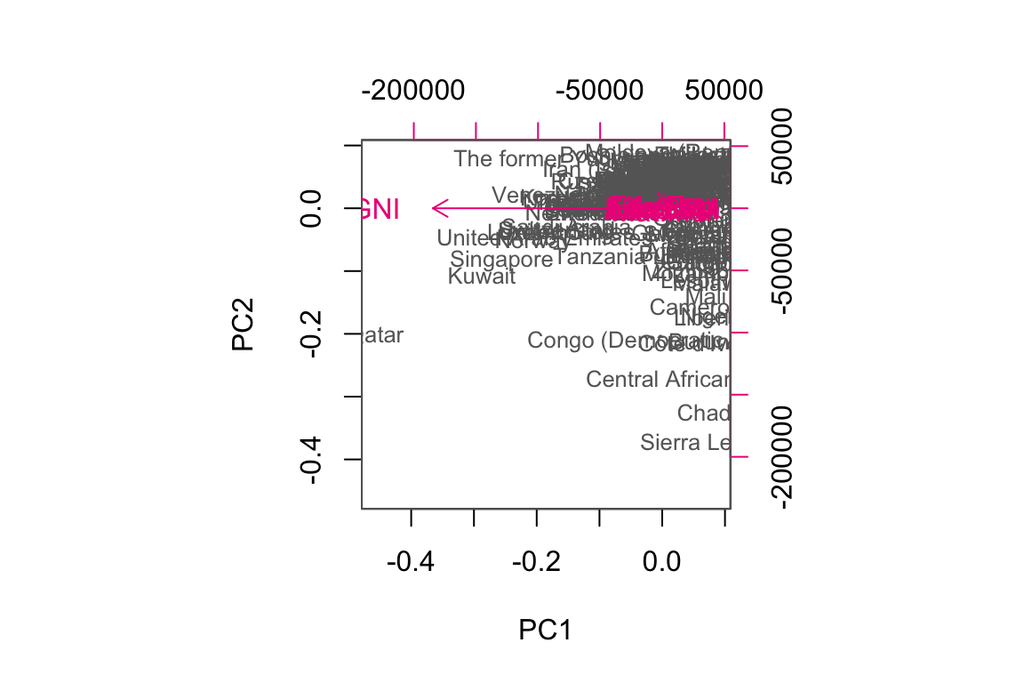

```r
pca_human_unstd<-prcomp(human)
us<-summary(human)
biplot(pca_human_unstd, cex=c(0.8,1), col=c("grey40","deeppink2"), xlab="PC1", ylab="PC2")
```

### the standized variables

```r
human_std<-scale(human)
```

### print out summaries of human_std

```r
summary(human_std)
```

```
##     Edu2.FM           Labo.FM           Edu.Exp           Life.Exp
##  Min.   :-2.8189   Min.   :-2.6247   Min.   :-2.7378   Min.   :-2.7188
##  1st Qu.:-0.5233   1st Qu.:-0.5484   1st Qu.:-0.6782   1st Qu.:-0.6425
##  Median : 0.3503   Median : 0.2316   Median : 0.1140   Median : 0.3056
##  Mean   : 0.0000   Mean   : 0.0000   Mean   : 0.0000   Mean   : 0.0000
##  3rd Qu.: 0.5958   3rd Qu.: 0.7350   3rd Qu.: 0.7126   3rd Qu.: 0.6717
##  Max.   : 2.6646   Max.   : 1.6632   Max.   : 2.4730   Max.   : 1.4218
##       GNI             Mat.Mor          Ado.Birth          Parli.F
##  Min.   :-0.9193   Min.   :-0.6992   Min.   :-1.1325   Min.   :-1.8203
##  1st Qu.:-0.7243   1st Qu.:-0.6496   1st Qu.:-0.8394   1st Qu.:-0.7409
##  Median :-0.3013   Median :-0.4726   Median :-0.3298   Median :-0.1403
##  Mean   : 0.0000   Mean   : 0.0000   Mean   : 0.0000   Mean   : 0.0000
##  3rd Qu.: 0.3712   3rd Qu.: 0.1932   3rd Qu.: 0.6030   3rd Qu.: 0.6127
##  Max.   : 5.6890   Max.   : 4.4899   Max.   : 3.8344   Max.   : 3.1850
```

### perform principal component analysis(with the SVD method)

```r
pca_human<-prcomp(human_std)
pca_human
```

```
## Standard deviations (1, .., p=8):
## [1] 2.0708380 1.1397204 0.8750485 0.7788630 0.6619563 0.5363061 0.4589994
## [8] 0.3222406
##
## Rotation (n x k) = (8 x 8):
##                   PC1         PC2         PC3         PC4        PC5
## Edu2.FM   -0.35664370  0.03796058 -0.24223089  0.62678110 -0.5983585
## Labo.FM    0.05457785  0.72432726 -0.58428770  0.06199424  0.2625067
## Edu.Exp   -0.42766720  0.13940571 -0.07340270 -0.07020294  0.1659678
## Life.Exp  -0.44372240 -0.02530473  0.10991305 -0.05834819  0.1628935
## GNI       -0.35048295  0.05060876 -0.20168779 -0.72727675 -0.4950306
## Mat.Mor    0.43697098  0.14508727 -0.12522539 -0.25170614 -0.1800657
## Ado.Birth  0.41126010  0.07708468  0.01968243  0.04986763 -0.4672068
## Parli.F   -0.08438558  0.65136866  0.72506309  0.01396293 -0.1523699
##                   PC6         PC7         PC8
## Edu2.FM    0.17713316  0.05773644  0.16459453
## Labo.FM   -0.03500707 -0.22729927 -0.07304568
## Edu.Exp   -0.38606919  0.77962966 -0.05415984
## Life.Exp  -0.42242796 -0.43406432  0.62737008
## GNI        0.11120305 -0.13711838 -0.16961173
## Mat.Mor    0.17370039  0.35380306  0.72193946
## Ado.Birth -0.76056557 -0.06897064 -0.14335186
## Parli.F    0.13749772  0.00568387 -0.02306476
```

### draw a biplot of the principan component representation and the original variables

```r
s<-summary(pca_human)
```

```r
pca_pr<-round(1*s$importance[2,], digits=1)
```

```r
pca_pr
```

```
## PC1 PC2 PC3 PC4 PC5 PC6 PC7 PC8
## 0.5 0.2 0.1 0.1 0.1 0.0 0.0 0.0
```

### create object pc_lab to be used as axis labels

```r
pc_lab<-paste0(names(pca_pr), "(", pca_pr, "%)")
```

### draw a biplot

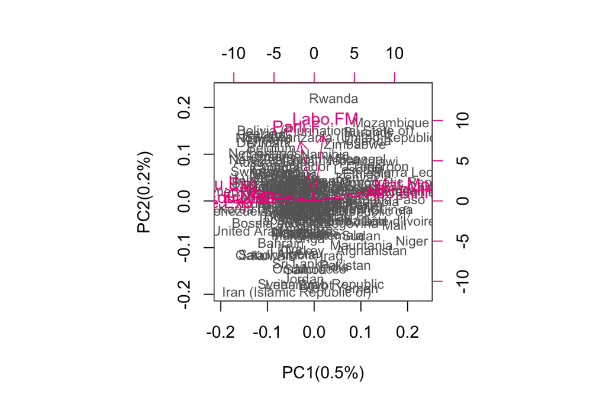

```r
biplot(pca_human, cex=c(0.8,1), col=c("grey40", "deeppink2"), xlab=pc_lab[1], ylab=pc_lab[2])
```

Unstandaized variables looks out of ranges because PCA is sensitive to the relatives scallings of the orginal variables and assumes that feature with larger varianace are more important than variables with smaller variabnce.

### Multiple Correspondence Analysis with Tea dataset

```r
library(FactoMineR)
library(ggplot2)
library(dplyr)
library(tidyr)
data("tea")
```

### keep column names in the dataset

```r
keep_columns<-c("Tea", "How","how","sugar","where","lunch")
```

### select the ‘keep_columns’ to create a new dataset

```r
tea_time<-select(tea, one_of(keep_columns))
```

### summaries and structure of the data

```r
summary(tea_time)
```

```
##         Tea         How                      how           sugar
##  black    : 74   alone:195   tea bag           :170   No.sugar:155
##  Earl Grey:193   lemon: 33   tea bag+unpackaged: 94   sugar   :145
##  green    : 33   milk : 63   unpackaged        : 36
##                  other:  9
##                   where           lunch
##  chain store         :192   lunch    : 44
##  chain store+tea shop: 78   Not.lunch:256
##  tea shop            : 30
##
```

```r
str(tea_time)
```

```
## 'data.frame':    300 obs. of  6 variables:
##  $ Tea  : Factor w/ 3 levels "black","Earl Grey",..: 1 1 2 2 2 2 2 1 2 1 ...
##  $ How  : Factor w/ 4 levels "alone","lemon",..: 1 3 1 1 1 1 1 3 3 1 ...
##  $ how  : Factor w/ 3 levels "tea bag","tea bag+unpackaged",..: 1 1 1 1 1 1 1 1 2 2 ...
##  $ sugar: Factor w/ 2 levels "No.sugar","sugar": 2 1 1 2 1 1 1 1 1 1 ...
##  $ where: Factor w/ 3 levels "chain store",..: 1 1 1 1 1 1 1 1 2 2 ...
##  $ lunch: Factor w/ 2 levels "lunch","Not.lunch": 2 2 2 2 2 2 2 2 2 2 ...
```

### visualize the dataset

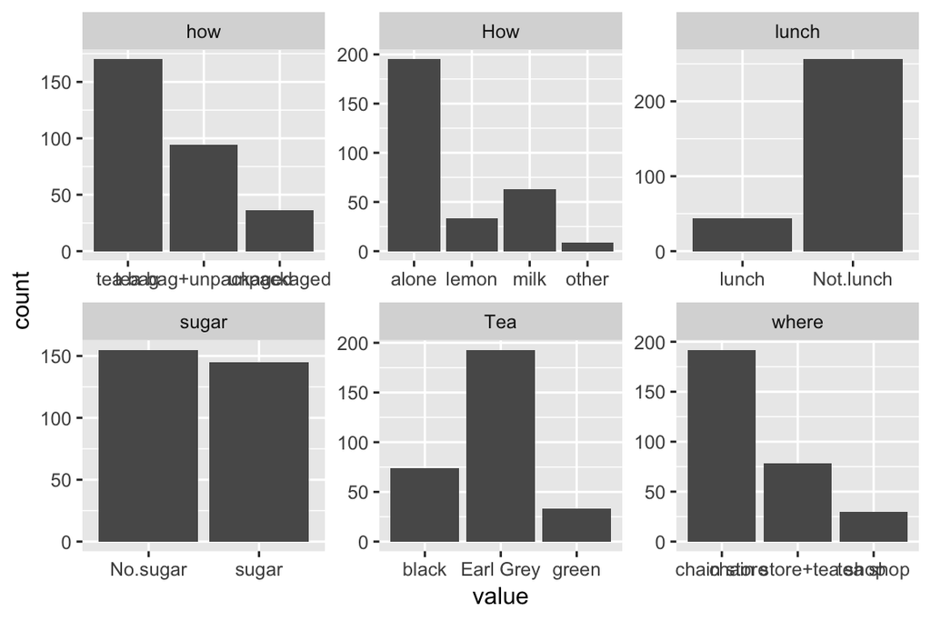

```r
gather(tea_time)%>%ggplot(aes(value))+facet_wrap("key",scales="free")+geom_bar()
```

### Multiple Corresondence Analysis

```r
mca<-MCA(tea_time, graph=FALSE)
```

### summary of the model

```r
summary(mca)
```

```
##
## Call:
## MCA(X = tea_time, graph = FALSE)
##
##
## Eigenvalues
##                        Dim.1   Dim.2   Dim.3   Dim.4   Dim.5   Dim.6
## Variance               0.279   0.261   0.219   0.189   0.177   0.156
## % of var.             15.238  14.232  11.964  10.333   9.667   8.519
## Cumulative % of var.  15.238  29.471  41.435  51.768  61.434  69.953
##                        Dim.7   Dim.8   Dim.9  Dim.10  Dim.11
## Variance               0.144   0.141   0.117   0.087   0.062
## % of var.              7.841   7.705   6.392   4.724   3.385
## Cumulative % of var.  77.794  85.500  91.891  96.615 100.000
##
## Individuals (the 10 first)
##                       Dim.1    ctr   cos2    Dim.2    ctr   cos2    Dim.3
## 1                  | -0.298  0.106  0.086 | -0.328  0.137  0.105 | -0.327
## 2                  | -0.237  0.067  0.036 | -0.136  0.024  0.012 | -0.695
## 3                  | -0.369  0.162  0.231 | -0.300  0.115  0.153 | -0.202
## 4                  | -0.530  0.335  0.460 | -0.318  0.129  0.166 |  0.211
## 5                  | -0.369  0.162  0.231 | -0.300  0.115  0.153 | -0.202
## 6                  | -0.369  0.162  0.231 | -0.300  0.115  0.153 | -0.202
## 7                  | -0.369  0.162  0.231 | -0.300  0.115  0.153 | -0.202
## 8                  | -0.237  0.067  0.036 | -0.136  0.024  0.012 | -0.695
## 9                  |  0.143  0.024  0.012 |  0.871  0.969  0.435 | -0.067
## 10                 |  0.476  0.271  0.140 |  0.687  0.604  0.291 | -0.650
##                       ctr   cos2
## 1                   0.163  0.104 |
## 2                   0.735  0.314 |
## 3                   0.062  0.069 |
## 4                   0.068  0.073 |
## 5                   0.062  0.069 |
## 6                   0.062  0.069 |
## 7                   0.062  0.069 |
## 8                   0.735  0.314 |
## 9                   0.007  0.003 |
## 10                  0.643  0.261 |
##
## Categories (the 10 first)
```

[output cut: 16 more lines]

```
## lemon                0.035   3.226 |   1.329  14.771   0.218   8.081 |
## milk                 0.020   2.422 |   0.013   0.003   0.000   0.116 |
## other                0.102   5.534 |  -2.524  14.526   0.197  -7.676 |
## tea bag              0.161  -6.941 |  -0.065   0.183   0.006  -1.287 |
## tea bag+unpackaged   0.478  11.956 |   0.019   0.009   0.000   0.226 |
## unpackaged           0.141  -6.482 |   0.257   0.602   0.009   1.640 |
##
## Categorical variables (eta2)
##                      Dim.1 Dim.2 Dim.3
## Tea                | 0.126 0.108 0.410 |
## How                | 0.076 0.190 0.394 |
## how                | 0.708 0.522 0.010 |
## sugar              | 0.065 0.001 0.336 |
## where              | 0.702 0.681 0.055 |
## lunch              | 0.000 0.064 0.111 |
```

### visualize MCA

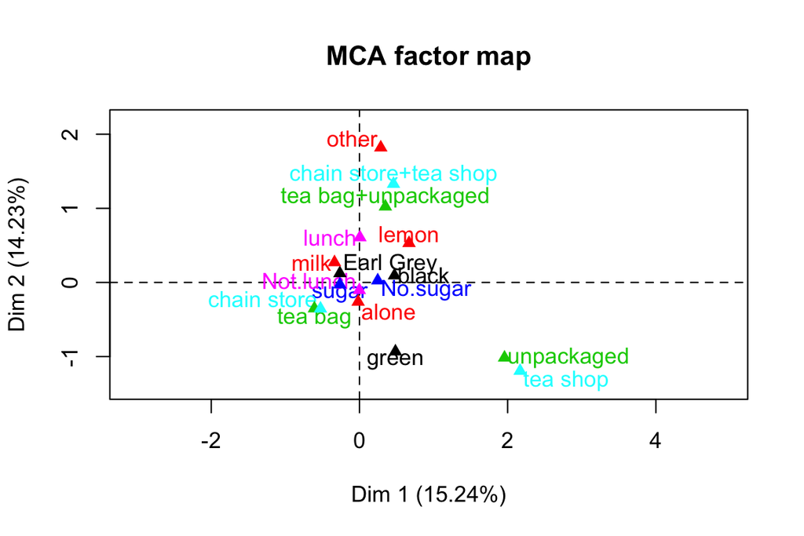

```r
plot(mca, invisible=c("ind"), habillage="quali")
```

# Chapter 6

### load and explore data

```r
BPRS<-read.table("https://raw.githubusercontent.com/KimmoVehkalahti/MABS/master/Examples/data/BPRS.txt", sep="", header=TRUE)
RATS<-read.table("https://raw.githubusercontent.com/KimmoVehkalahti/MABS/master/Examples/data/rats.txt", sep="\t", header=T)
str(BPRS)
```

```
## 'data.frame':    40 obs. of  11 variables:
##  $ treatment: int  1 1 1 1 1 1 1 1 1 1 ...
##  $ subject  : int  1 2 3 4 5 6 7 8 9 10 ...
##  $ week0    : int  42 58 54 55 72 48 71 30 41 57 ...
##  $ week1    : int  36 68 55 77 75 43 61 36 43 51 ...
##  $ week2    : int  36 61 41 49 72 41 47 38 39 51 ...
##  $ week3    : int  43 55 38 54 65 38 30 38 35 55 ...
##  $ week4    : int  41 43 43 56 50 36 27 31 28 53 ...
##  $ week5    : int  40 34 28 50 39 29 40 26 22 43 ...
##  $ week6    : int  38 28 29 47 32 33 30 26 20 43 ...
##  $ week7    : int  47 28 25 42 38 27 31 25 23 39 ...
##  $ week8    : int  51 28 24 46 32 25 31 24 21 32 ...
```

```r
summary(BPRS)
```

```
##    treatment      subject          week0           week1
##  Min.   :1.0   Min.   : 1.00   Min.   :24.00   Min.   :23.00
##  1st Qu.:1.0   1st Qu.: 5.75   1st Qu.:38.00   1st Qu.:35.00
##  Median :1.5   Median :10.50   Median :46.00   Median :41.00
##  Mean   :1.5   Mean   :10.50   Mean   :48.00   Mean   :46.33
##  3rd Qu.:2.0   3rd Qu.:15.25   3rd Qu.:58.25   3rd Qu.:54.25
##  Max.   :2.0   Max.   :20.00   Max.   :78.00   Max.   :95.00
##      week2          week3           week4           week5
##  Min.   :26.0   Min.   :24.00   Min.   :20.00   Min.   :20.00
##  1st Qu.:32.0   1st Qu.:29.75   1st Qu.:28.00   1st Qu.:26.00
##  Median :38.0   Median :36.50   Median :34.50   Median :30.50
##  Mean   :41.7   Mean   :39.15   Mean   :36.35   Mean   :32.55
##  3rd Qu.:49.0   3rd Qu.:44.50   3rd Qu.:43.00   3rd Qu.:38.00
##  Max.   :75.0   Max.   :76.00   Max.   :66.00   Max.   :64.00
##      week6           week7          week8
##  Min.   :19.00   Min.   :18.0   Min.   :20.00
##  1st Qu.:22.75   1st Qu.:23.0   1st Qu.:22.75
##  Median :28.50   Median :30.0   Median :28.00
##  Mean   :31.23   Mean   :32.2   Mean   :31.43
##  3rd Qu.:37.00   3rd Qu.:38.0   3rd Qu.:35.25
##  Max.   :64.00   Max.   :62.0   Max.   :75.00
```

```r
str(RATS)
```

```
## 'data.frame':    16 obs. of  13 variables:
##  $ ID   : int  1 2 3 4 5 6 7 8 9 10 ...
##  $ Group: int  1 1 1 1 1 1 1 1 2 2 ...
##  $ WD1  : int  240 225 245 260 255 260 275 245 410 405 ...
##  $ WD8  : int  250 230 250 255 260 265 275 255 415 420 ...
##  $ WD15 : int  255 230 250 255 255 270 260 260 425 430 ...
##  $ WD22 : int  260 232 255 265 270 275 270 268 428 440 ...
##  $ WD29 : int  262 240 262 265 270 275 273 270 438 448 ...
##  $ WD36 : int  258 240 265 268 273 277 274 265 443 460 ...
##  $ WD43 : int  266 243 267 270 274 278 276 265 442 458 ...
##  $ WD44 : int  266 244 267 272 273 278 271 267 446 464 ...
##  $ WD50 : int  265 238 264 274 276 284 282 273 456 475 ...
##  $ WD57 : int  272 247 268 273 278 279 281 274 468 484 ...
##  $ WD64 : int  278 245 269 275 280 281 284 278 478 496 ...
```

```r
summary(RATS)
```

```
##        ID            Group           WD1             WD8
##  Min.   : 1.00   Min.   :1.00   Min.   :225.0   Min.   :230.0
##  1st Qu.: 4.75   1st Qu.:1.00   1st Qu.:252.5   1st Qu.:255.0
##  Median : 8.50   Median :1.50   Median :340.0   Median :345.0
##  Mean   : 8.50   Mean   :1.75   Mean   :365.9   Mean   :369.1
##  3rd Qu.:12.25   3rd Qu.:2.25   3rd Qu.:480.0   3rd Qu.:476.2
##  Max.   :16.00   Max.   :3.00   Max.   :555.0   Max.   :560.0
##       WD15            WD22            WD29            WD36
##  Min.   :230.0   Min.   :232.0   Min.   :240.0   Min.   :240.0
##  1st Qu.:255.0   1st Qu.:267.2   1st Qu.:268.8   1st Qu.:267.2
##  Median :347.5   Median :351.5   Median :356.5   Median :360.0
##  Mean   :372.5   Mean   :379.2   Mean   :383.9   Mean   :387.0
##  3rd Qu.:486.2   3rd Qu.:492.5   3rd Qu.:497.8   3rd Qu.:504.2
##  Max.   :565.0   Max.   :580.0   Max.   :590.0   Max.   :597.0
##       WD43            WD44            WD50            WD57
##  Min.   :243.0   Min.   :244.0   Min.   :238.0   Min.   :247.0
##  1st Qu.:269.2   1st Qu.:270.0   1st Qu.:273.8   1st Qu.:273.8
##  Median :360.0   Median :362.0   Median :370.0   Median :373.5
##  Mean   :386.0   Mean   :388.3   Mean   :394.6   Mean   :398.6
##  3rd Qu.:501.0   3rd Qu.:510.5   3rd Qu.:516.0   3rd Qu.:524.5
##  Max.   :595.0   Max.   :595.0   Max.   :612.0   Max.   :618.0
##       WD64
##  Min.   :245.0
##  1st Qu.:278.0
##  Median :378.0
##  Mean   :404.1
##  3rd Qu.:530.8
##  Max.   :628.0
```

```r
library(dplyr)
library(tidyr)
```

### Covert the catergorical variable of the dataset to factors

### BPRS

#### Factor treatment & subject

```r
BPRS$treatment <- factor(BPRS$treatment)
BPRS$subject <- factor(BPRS$subject)
```

#### Convert to long form

```r
BPRSL <-  BPRS %>% gather(key = weeks, value = bprs, -treatment, -subject)
```

#### Extract the week number

```r
BPRSL <-  BPRSL %>% mutate(week = as.integer(substr(weeks, 5,5)))
```

#### Take a glimpse at the BPRSL data

```r
glimpse(BPRSL)
```

```
## Observations: 360
## Variables: 5
## $ treatment <fct> 1, 1, 1, 1, 1, 1, 1, 1, 1, 1, 1, 1, 1, 1, 1, 1, 1, 1...
## $ subject   <fct> 1, 2, 3, 4, 5, 6, 7, 8, 9, 10, 11, 12, 13, 14, 15, 1...
## $ weeks     <chr> "week0", "week0", "week0", "week0", "week0", "week0"...
## $ bprs      <int> 42, 58, 54, 55, 72, 48, 71, 30, 41, 57, 30, 55, 36, ...
## $ week      <int> 0, 0, 0, 0, 0, 0, 0, 0, 0, 0, 0, 0, 0, 0, 0, 0, 0, 0...
```

### graphical displays of individuals

#### draw the plot

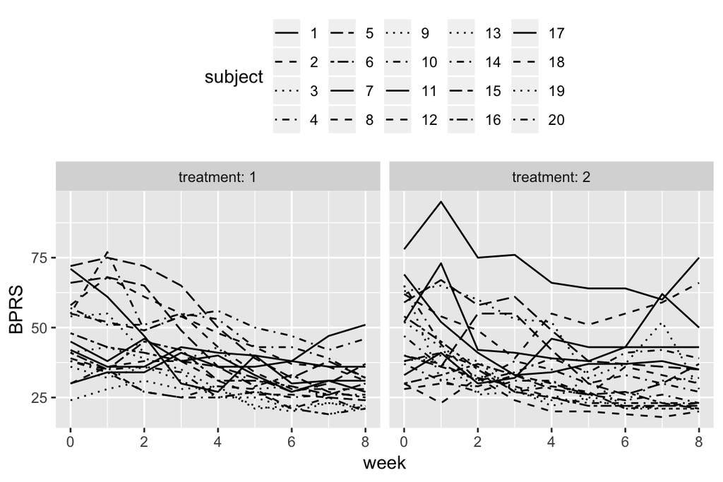

```r
library(ggplot2)
ggplot(BPRSL, aes(x=week, y=bprs, linetype=subject))+
  geom_line()+
  scale_linetype_manual(values=rep(1:10, times=4))+
  facet_grid(.~treatment, labeller = label_both)+
  theme(legend.position = "top")+
  scale_y_continuous(limits = c(min(BPRSL$bprs), max(BPRSL$bprs)), name=("BPRS"))
```

####standardise the variable bprs

```r
BPRSL<- BPRSL%>%
  group_by(week)%>%
  mutate(stdbprs = ((bprs-mean(bprs))/sd(bprs))) %>%
  ungroup()
```

#### glimps at the data

```r
glimpse(BPRSL)
```

```
## Observations: 360
## Variables: 6
## $ treatment <fct> 1, 1, 1, 1, 1, 1, 1, 1, 1, 1, 1, 1, 1, 1, 1, 1, 1, 1...
## $ subject   <fct> 1, 2, 3, 4, 5, 6, 7, 8, 9, 10, 11, 12, 13, 14, 15, 1...
## $ weeks     <chr> "week0", "week0", "week0", "week0", "week0", "week0"...
## $ bprs      <int> 42, 58, 54, 55, 72, 48, 71, 30, 41, 57, 30, 55, 36, ...
## $ week      <int> 0, 0, 0, 0, 0, 0, 0, 0, 0, 0, 0, 0, 0, 0, 0, 0, 0, 0...
## $ stdbprs   <dbl> -0.4245908, 0.7076513, 0.4245908, 0.4953559, 1.69836...
```

[figure not shown]

```r
ggplot(BPRSL, aes(x=week, y=bprs, linetype=subject))+
  geom_line()+
  scale_linetype_manual(values=rep(1:10, time = 4))+
  facet_grid(.~treatment, labeller = label_both)+
  scale_y_continuous(name = "standardized bprs")
```

```r
n <- BPRSL%>%unique()%>% length()
```

#### summary data with and standard error of bprs by treatment and week

```r
BPRSS<-BPRSL%>%
  group_by(treatment, week)%>%
  summarise( mean = mean(bprs), se =sd(bprs)/sqrt(n))%>%
  ungroup()
```

#### glimpse at the data

```r
glimpse(BPRSS)
```

```
## Observations: 18
## Variables: 4
## $ treatment <fct> 1, 1, 1, 1, 1, 1, 1, 1, 1, 2, 2, 2, 2, 2, 2, 2, 2, 2
## $ week      <int> 0, 1, 2, 3, 4, 5, 6, 7, 8, 0, 1, 2, 3, 4, 5, 6, 7, 8
## $ mean      <dbl> 47.00, 46.80, 43.55, 40.90, 36.60, 32.70, 29.70, 29....
## $ se        <dbl> 5.553567, 6.336472, 4.903409, 4.586211, 3.992097, 3....
```

#### plot the mean profiles

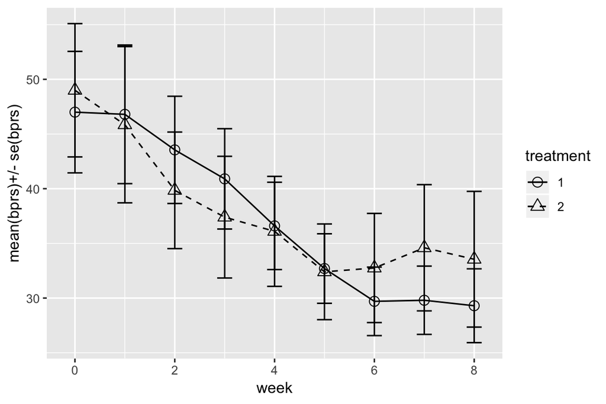

```r
ggplot(BPRSS, aes(x=week, y=mean, linetype=treatment, shape=treatment))+
  geom_line()+
  scale_linetype_manual(values= c(1,2) )+
  geom_point(size=3)+
  scale_shape_manual(values=c(1,2))+
  geom_errorbar(aes(ymin=mean-se, ymax=mean+se, linetype="1"), width=0.3)+
  scale_y_continuous(name= "mean(bprs)+/- se(bprs)")
```

### Find outliers

#### create a summary data by treatment and subject with mean as the summary variable

```r
BPRSL8S<-BPRSL%>%
  filter(week >0 )%>%
  group_by(treatment, subject)%>%
  summarise(mean = mean(bprs))%>%
  ungroup()
```

#### glipse at the data

```r
glimpse(BPRSL8S)
```

```
## Observations: 40
## Variables: 3
## $ treatment <fct> 1, 1, 1, 1, 1, 1, 1, 1, 1, 1, 1, 1, 1, 1, 1, 1, 1, 1...
## $ subject   <fct> 1, 2, 3, 4, 5, 6, 7, 8, 9, 10, 11, 12, 13, 14, 15, 1...
## $ mean      <dbl> 41.500, 43.125, 35.375, 52.625, 50.375, 34.000, 37.1...
```

#### draw a boxplot of the mean versus treatment

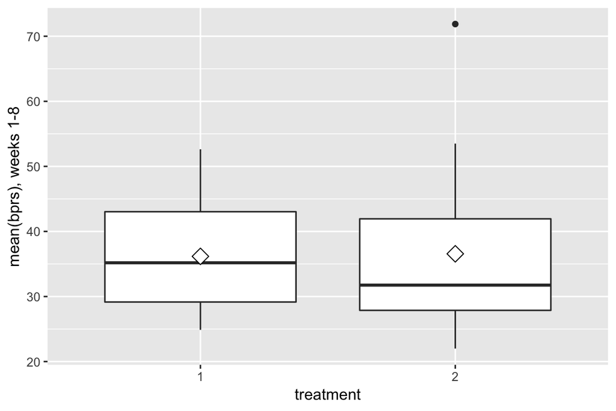

```r
ggplot(BPRSL8S, aes(x = treatment, y= mean))+
  geom_boxplot()+
  stat_summary(fun.y="mean", geom="point", shape=23, size =4, fill= "white")+
  scale_y_continuous(name="mean(bprs), weeks 1-8")
```

####create a new data by filtering th outlier

```r
BPRSL8S1<-BPRSL8S%>%
  filter(mean<60)
```